# Advanced Predict Assignment Writeup

Wendi YANG_67609_EDHEC Business School

# 1.Overview

Using devices such as Jawbone Up, Nike FuelBand, and Fitbit it is now possible to collect a large amount of data about personal activity relatively inexpensively. These devices are part of the quantified self movement - a group of enthusiasts who take measurements about themselves regularly to improve their health, to find patterns in their behavior, or because they are tech geeks. One thing that people regularly do is quantify how much of a particular activity they do, but they rarely quantify how well they do it.

The objective of this report is to demonstrate the process employed to arrive at a prediction algorithm, which aims to classify the manner in which the participants employed certain exercises. The data comes from accelerometers attached on the belt, forearm and dumbells.

# 2.Introduction

The goal of Predict Assignment Writeup is to predict the manner in which 6 participants did a weight lifting exercise. For this, I downloaded a training dataset and a test dataset and then created a model, used cross validation, calculated an expected out of sample error. In this write-up, I would also describe how I built the model, and why I made the choices that I did. I also used the model to predict the 20 test cases.

# 3.Dataset Overview

## 3.1 Dataset Loading

From the URL provided from the Coursera, I download from the link and then get the original training dataset and test dataset.

```r
#Environment uploading R libraries
install.packages(c("lattice","ggplot2","dplyr","randomForest","gridExtra","rattle","tibble","bitops"))
```

[output not shown]

```r
library(ggplot2)
library(rattle)
library(dplyr)
library(randomForest)
library(corrplot)
library(rpart)
library(rpart.plot)
library(knitr)
library(caret)
library(corrplot)
library(lattice)
library(gridExtra)
library(grid)

#data loading
urltrain <- "https://d396qusza40orc.cloudfront.net/predmachlearn/pml-training.csv"
urltest <- "https://d396qusza40orc.cloudfront.net/predmachlearn/pml-testing.csv"
training <- read.csv(url(urltrain), na.strings = c("NA","#DIV/0!",""))
install.packages(c("lattice", "ggplot2", "dplyr", "randomForest", "gridExtra", "rattle", "tibble", "bitops"))
```

[output not shown]

[output not shown]

[output not shown]

```r
testing <- read.csv(url(urltest), na.strings = c("NA","#DIV/0!",""))

dim(training)
```

```
[1] 19622   160
```

```r
dim(testing)
```

```
[1]  20 160
```

```r
head(sapply(training, function(x) sum(is.na(x))), n=30)
```

```
                   X            user_name raw_timestamp_part_1 raw_timestamp_part_2       cvtd_timestamp
                   0                    0                    0                    0                    0
          new_window           num_window            roll_belt           pitch_belt             yaw_belt
                   0                    0                    0                    0                    0
    total_accel_belt   kurtosis_roll_belt  kurtosis_picth_belt    kurtosis_yaw_belt   skewness_roll_belt
                   0                19226                19248                19622                19225
skewness_roll_belt.1    skewness_yaw_belt        max_roll_belt       max_picth_belt         max_yaw_belt
               19248                19622                19216                19216                19226
       min_roll_belt       min_pitch_belt         min_yaw_belt  amplitude_roll_belt amplitude_pitch_belt
               19216                19216                19226                19216                19216
  amplitude_yaw_belt var_total_accel_belt        avg_roll_belt     stddev_roll_belt        var_roll_belt
               19226                19216                19216                19216                19216
```

The dataset consists 160 variables in all, excluding the outcome variable “Classe”, there are 159 candidates to be included as predictors. However, a close examination of the data would indicate that some variables might not be usefull in this model. As we can see, some variables have plenty of missing values NA.

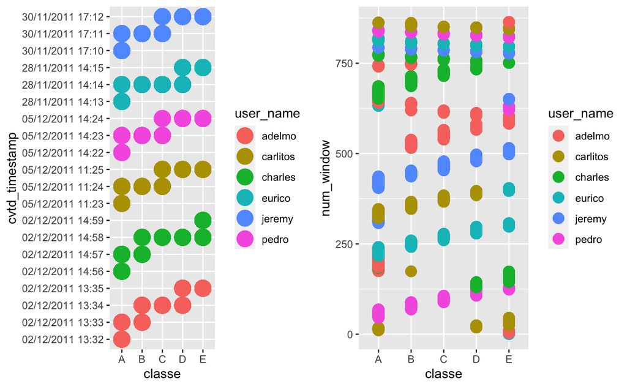

```r
qplot1 <- qplot(classe, cvtd_timestamp, data = training, color=user_name,size=I(6))
qplot2 <-qplot(classe, num_window, data = training, color=user_name, size=I(4))
grid.arrange(qplot1, qplot2,ncol=2)
```